# Analysis of Chicane Results for RADICL-Seq Data

Alan Murphy

Most recent update: 2021-06-22

```r
#root.dir <- here::here()
knitr::opts_chunk$set(
  collapse = TRUE,
  comment = "#>",
  #root.dir = root.dir
  fig.height = 6,
  fig.width = 7.00787 #178mm
)
knitr::opts_knit$set(#root.dir = root.dir,
                     dpi = 350)

library(data.table)
library(ggplot2)
library(cowplot)
library(ggplot2)
library(viridis)
library(dplyr)
library(genomation)
library(biomaRt)
```

## Chicane Results & Preprocessing

The results from `Chicane` do contain NA values (we have queried with the authors why this occured and are awaiting a response), we first remove these and also add an adjusted p-value groupings for our interactions for later use:

```r
res <-
    fread("/rds/general/project/neurogenomics-lab/live/Projects/radicl_seq/data/chicane.results.rdcl.txt")
#50k NA's are removed
res <- res[!is.na(p.value)]
#make bins split res by q.value bins -
#go with 0.05 separate as relatively high num and so you get q.val<0.05
#split rest by .2
res[,q_bin:=cut(q.value,breaks=c(0,0.05,0.2,0.4,0.6,0.8,1))]
```

## Distance of Interactions from Transcriptional Start Site

To validate the `Chicane` model for use with RADICL-Seq data, we hypothesised that there would be a build up of interacitons found close to the Transcriptional Start Site of the RNA in question. Since this is more likely to occur due to random chance, we hoped `Chicane` would take this into account and that the significant interactions would not be all in this region.

**NOTE** - Since this analysis is based on distance, trans interactions which account for 88.4% of all interactions, could not be included.

First, prepare the data for plotting:

```r
#need to split out separate row for each count in count column to get density plot
#remove trans interactions....
res_stretch_cis <- res[!is.na(distance),.(count2=1:count),names(res)]
```

Now we can plot. Since we plot the distance on a Log 10 scale, we have added lines at 60Kb and 300Kb to make the plots easier to interpret.

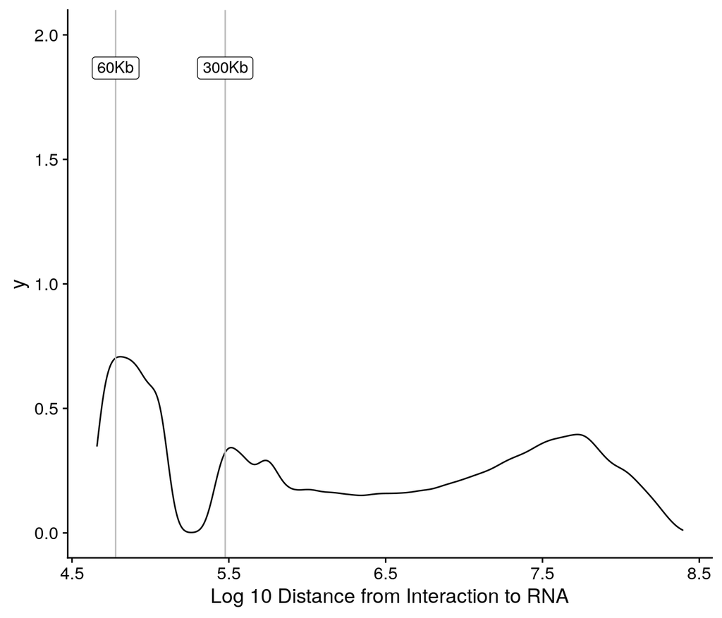

```r
ggplot(res_stretch_cis, aes(log(distance,base=10))) +
    geom_density(alpha = 0.1)+theme_cowplot()+
    scale_fill_viridis(name="Adj. P-value Bin",discrete=T)+
    scale_colour_viridis(name="Adj. P-value Bin",discrete=T)+
    geom_vline(xintercept=log(60000,base=10), colour="grey") +
    geom_vline(xintercept=log(300000,base=10), colour="grey") +
    annotate(x=log(60000,base=10),y=2,label="60Kb",vjust=2,geom="label")+
    annotate(x=log(300000,base=10),y=2,label="300Kb",vjust=2,geom="label")+
    xlab("Log 10 Distance from Interaction to RNA")
```

As can be seen, there is an initial peak of interactions close to the TSS. This proves that, as expected, we observe a pile up of interactions at the TSS.There are also two other, smaller peaks in the number of interactions at further distances.

We ideally want a model which can account for this pile up of interactions which is more likely due to random chance. We can check if `Chicane` has accounted for this by splitting the data based on the interactions’ adjusted p-value scores:

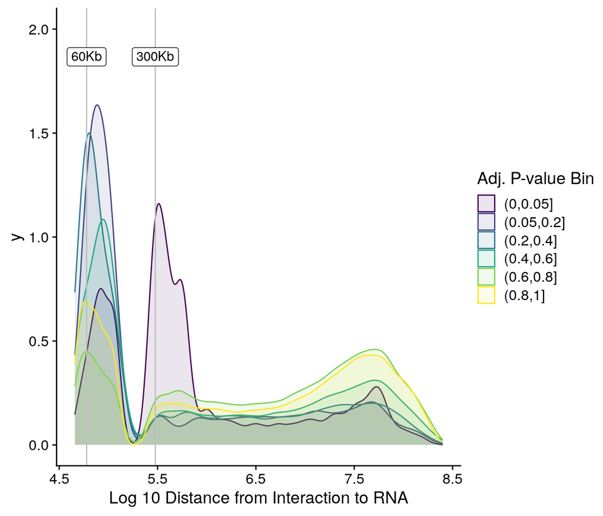

```r
#split by groups
ggplot(res_stretch_cis, aes(log(distance,base=10),
                                fill = q_bin, colour = q_bin)) +
    geom_density(alpha = 0.1)+theme_cowplot()+
    scale_fill_viridis(name="Adj. P-value Bin",discrete=T)+
    scale_colour_viridis(name="Adj. P-value Bin",discrete=T)+
    geom_vline(xintercept=log(60000,base=10), colour="grey") +
    geom_vline(xintercept=log(300000,base=10), colour="grey") +
    annotate(x=log(60000,base=10),y=2,label="60Kb",vjust=2,geom="label")+
    annotate(x=log(300000,base=10),y=2,label="300Kb",vjust=2,geom="label")+
    xlab("Log 10 Distance from Interaction to RNA")
```

The significant (Adj p-value<0.05) interactions have a peak in interactions further away from the TSS, showing `Chicane` does account for interactions which are more likely due to random chance with fewer of those that are close to the TSS being significant.

Finally, we hypothesised that the length of interacting RNA could play a role in the distance of the interaction from the TSS. To investigate this, we first have to standardise the base pair distance by the RNA length before replotting:

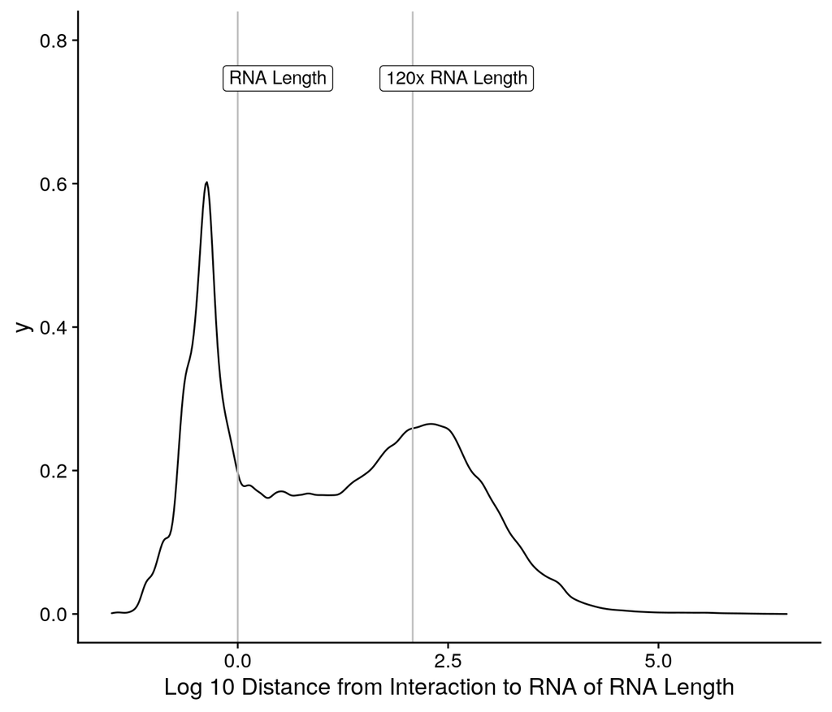

```r
res_stretch_cis[,bait.length:=bait.end-bait.start]
res_stretch_cis[,stnd_dist:=distance/bait.length]

ggplot(res_stretch_cis, aes(log(stnd_dist,base=10))) +
    geom_density(alpha = 0.1)+theme_cowplot()+
    scale_fill_viridis(name="Adj. P-value Bin",discrete=T)+
    scale_colour_viridis(name="Adj. P-value Bin",discrete=T)+
    geom_vline(xintercept=log(1,base=10), colour="grey") +
    geom_vline(xintercept=log(120,base=10), colour="grey") +
    annotate(x=log(3,base=10),y=.8,label="RNA Length",vjust=2,geom="label")+
    annotate(x=log(400,base=10),y=.8,label="120x RNA Length",vjust=2,
             geom="label")+
    xlab("Log 10 Distance from Interaction to RNA of RNA Length")
```

Taking into account RNA length leaves just two peaks of the number interactions, one occuring where the distance is within the length of the RNA in question and another at a distance over 120x the length of the RNA away.

How does controlling for RNA length affect the significant interaction counts:

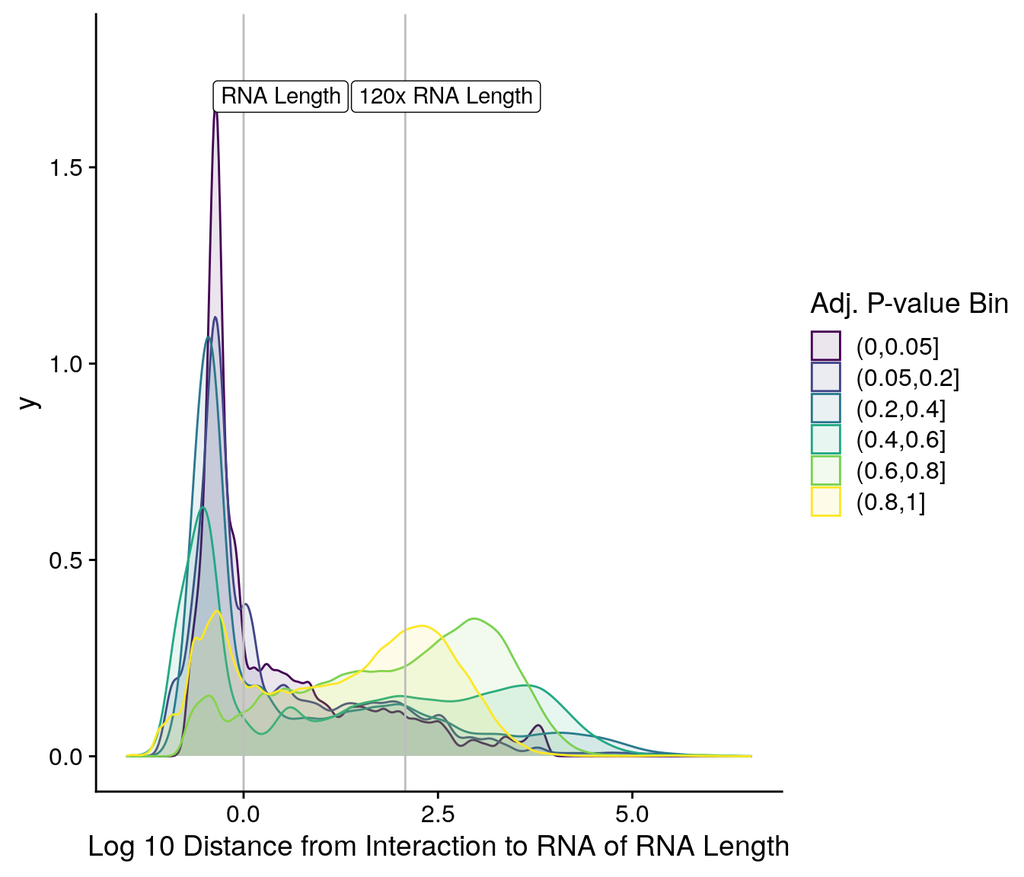

```r
ggplot(res_stretch_cis, aes(log(stnd_dist,base=10),
                            fill = q_bin, colour = q_bin)) +
    geom_density(alpha = 0.1)+theme_cowplot()+
    scale_fill_viridis(name="Adj. P-value Bin",discrete=T)+
    scale_colour_viridis(name="Adj. P-value Bin",discrete=T)+
    geom_vline(xintercept=log(1,base=10), colour="grey") +
    geom_vline(xintercept=log(120,base=10), colour="grey") +
    annotate(x=log(3,base=10),y=1.8,label="RNA Length",vjust=2,geom="label")+
    annotate(x=log(400,base=10),y=1.8,label="120x RNA Length",vjust=2,
                geom="label")+
    xlab("Log 10 Distance from Interaction to RNA of RNA Length")
```

The vast majority of cis significant interactions occur at a distance from the TSS within the length of the RNA. This is interesting as the more distant peak in the significant interactions is removed when you control for RNA length.

This made us question if there is a relationship between the adjusted p-value and the RNA length. We would hope that there wouldn’t be a strong relationship as, if there was, it may indicate that `Chicane` which is meant to be used for DNA-DNA interaction data (e.g. Capture Hi-C) may not be suitable for RNA-DNA interaction data (RADICL-Seq). DNA-DNA interaction dataset models may not need to control for the length of the DNA that binds since this wouldn’t fluctuate as much as RNA length in RNA-DNA interactions. To test this we performed a simple non-parametric correlation test on the cis interactions:

```r
#is there a relationship between RNA length and q-value?
cor.test(res_stretch_cis$bait.length,res_stretch_cis$q.value,
            method = "spearman",exact = F)
```

```
#>
#>  Spearman's rank correlation rho
#>
#> data:  res_stretch_cis$bait.length and res_stretch_cis$q.value
#> S = 1.2863e+19, p-value < 2.2e-16
#> alternative hypothesis: true rho is not equal to 0
#> sample estimates:
#>       rho
#> 0.1443764
```

This correlation test actually showed the opposite, an increase in RNA length was related to an increase in adjusted p-value. This proved that the significant interactions produced by `Chicane` were not driven by the RNA length and thus increased our confidence int he use of the model for this data type.

## ChromHMM Chromatin States where Interactions Occur

ChromHMM reference datasets can be used to infer the differing regulatory sections of the genome e.g. active Transcriptional Start Sites. We wanted to investiage in which chromatin states, the interactions found by RADICL-Seq were more frequently found. The RADICL-Seq data was from NiGa cells from differentiated human adipose-derived stem cells thus we used the [Adipose Derived Mesenchymal Stem Cell Cultured Cells (hg38) E025 reference map from Roadmap](https://egg2.wustl.edu/roadmap/data/byFileType/chromhmmSegmentations/ChmmModels/coreMarks/jointModel/final/). Matching the cell type ensured no differing, celltype specific epigenetic features.

The reference map can be loaded as follows:

```
#E025 Adipose Derived Mesenchymal Stem Cell Cultured Cells - hg38
#from: https://egg2.wustl.edu/roadmap/data/byFileType/chromhmmSegmentations/ChmmModels/coreMarks/jointModel/final/
#This bed file only contains one metadata column so genomation::readBed will fail
#Approach below uses code from in this function
chrHMM_url <-
    "https://egg2.wustl.edu/roadmap/data/byFileType/chromhmmSegmentations/ChmmModels/coreMarks/jointModel/final/E025_15_coreMarks_hg38lift_segments.bed.gz"
file <- genomation:::compressedAndUrl2temp(chrHMM_url)
#read in as dataframe
df<-readr::read_delim(file,skip=0,col_names=FALSE, delim="\t")
names(df) <- c("chr","start","end","ChromHMM")
#make GRanges obj
g = GenomicRanges::makeGRangesFromDataFrame(
    df,
    keep.extra.columns=FALSE,
    starts.in.df.are.0based=FALSE,
    ignore.strand=is.null(NULL))
col.names1=list(chr=1,start=2,end=3,strand=NULL)
black.names=c("seqnames", "ranges", "strand", "seqlevels", "seqlengths",
              "isCircular", "start", "end", "width", "element")
my.mcols = df[,-unlist(col.names1),drop=FALSE]
#add meta data column
GenomicRanges::mcols(g) = my.mcols[, !colnames(my.mcols) %in% black.names]
#split GRange object by the different names
chrHMM_list <- GenomicRanges::split(g, g$ChromHMM, drop = TRUE)
#get state names for IDs
sort(unique(df$ChromHMM))
```

The 15 states associated with the reference map are discussed [here](https://www.nature.com/articles/nature14309) but in short are:

- 1_TssA active transcription start site (TSS) -proximal promoter states
- 2_TssAFlnk Flanking active transcription start site (TSS). -proximal promoter states
- 3_TxFlnk a transcribed state at the 5′ and 3′ end of genes -showing both promoter and enhancer signatures
- 4_Tx Strong transcription
- 5_TxWk Weak transcription
- 6_EnhG Genic enhancer -genic enhancers occur more frequently in gene bodies & in exons, while enhancers don’t
- 7_Enh enhancers
- 8_ZNF/Rpts zinc finger protein genes and repeats. -ZNFs are involved in the regulation of several cellular processes (v abundant)
- 9_Het heterochromatin. - tightly packed DNA, inactive states
- 10_TssBiv bivalent/poised transcription start site. -both activation and repression (low expression), poised to express
- 11_BivFlnk flanking bivalent transcription start site/enhancer
- 12_EnhBiv bivalent enhancer
- 13_ReprPC repressed Polycomb. -gene silencing
- 14_ReprPCWk weak repressed Polycomb
- 15_Quies quiescent/low - inactivity/dormitary

Roughly, states 1-7 are active transcriptional sites while 8-15 are inactive or poised.

We need to preprocess and convert our `Chicane` results into a GRange object to compare overlapping regions with our reference map. We want to split the results based on the adjusted p-value groups were created earlier:

```
setnames(res,c("target.chr","target.start","target.end"),
            c("chr","start","end"))
            #make GRanges
gres = GenomicRanges::makeGRangesFromDataFrame(
    res,
    keep.extra.columns=TRUE,
    starts.in.df.are.0based=FALSE,
    ignore.strand=TRUE)
#now split based on q-value bins
gres_list <- GenomicRanges::split(gres, gres$q_bin, drop = TRUE)
rm(gres)
```

Now we can make an annotation object using `genomation` which inspects the regions of the genome where interactions were found:

```
annotation <-
    genomation::annotateWithFeatures(gres_list, chrHMM_list)
```

Next we can get the overlap percentages of the interactions to each of the different states.

**Note** that this won’t add up to 100% for each adjusted p-value group since it measures the proportion of the DNA segment from the interaction that overlaps a specific state. A single interaction could be split across states, for example with 20% of its base pairs in a active TSS (state 1) and 70% of its base pairs in a flanking active TSS (state 2) and the remaining 10% in a unmarked region of DNA.

```r
#don't produce heatmap, take matrix, standardise and replot
annot_mtrx <- genomation::heatTargetAnnotation(annotation,plot=FALSE)
#change column order
col.order <- paste0("E",1:15)
annot_mtrx <- annot_mtrx[,col.order]
```

Now we can plot and see where our interactions lie:

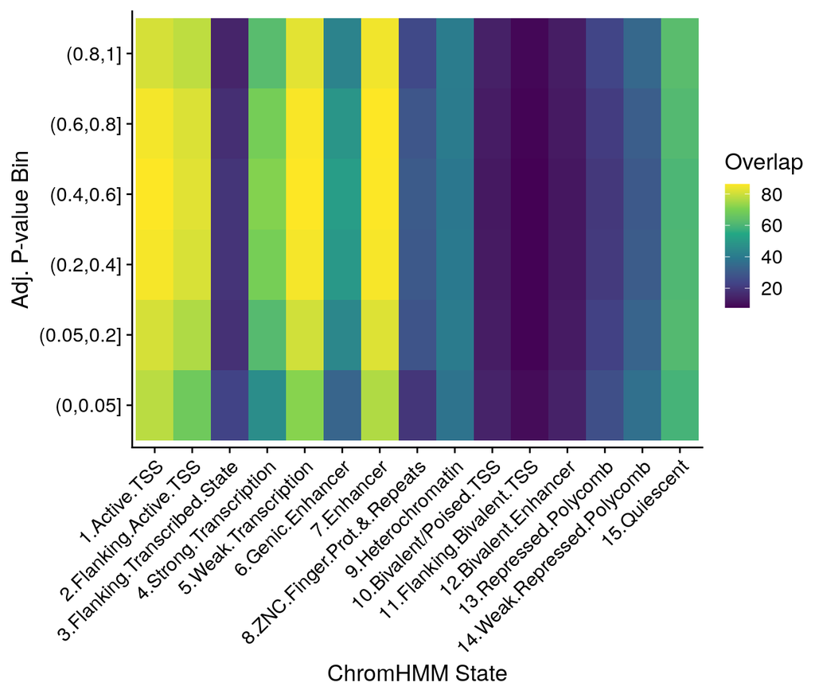

```r
#plot raw first
#convert to df
annot_df<-reshape2::melt(annot_mtrx)
names(annot_df) <- c("q-value","State","Overlap")
#Add better explaining state names
annot_df <- annot_df%>%
    mutate(State_name = as.factor(case_when(
        .$State == "E1" ~ "1.Active.TSS",
        .$State == "E2" ~ "2.Flanking.Active.TSS",
        .$State == "E3" ~ "3.Flanking.Transcribed.State",
        .$State == "E4" ~ "4.Strong.Transcription",
        .$State == "E5" ~ "5.Weak.Transcription",
        .$State == "E6" ~ "6.Genic.Enhancer",
        .$State == "E7" ~ "7.Enhancer",
        .$State == "E8" ~ "8.ZNC.Finger.Prot.&.Repeats",
        .$State == "E9" ~ "9.Heterochromatin",
        .$State == "E10" ~ "10.Bivalent/Poised.TSS",
        .$State == "E11" ~ "11.Flanking.Bivalent.TSS",
        .$State == "E12" ~ "12.Bivalent.Enhancer",
        .$State == "E13" ~ "13.Repressed.Polycomb",
        .$State == "E14" ~ "14.Weak.Repressed.Polycomb",
        .$State == "E15" ~ "15.Quiescent")))

# Reorder factor levels for plot
annot_df$State_name <-
    factor(annot_df$State_name,
            levels = levels(annot_df$State_name)[c(1,8:15,2:7)])
ggplot(annot_df,aes(x=State_name,y=`q-value`,fill=Overlap))+
    geom_tile()+theme_cowplot()+scale_fill_viridis_c()+
    theme(axis.text.x = element_text(angle = 45, hjust = 1))+
    xlab("ChromHMM State")+
    ylab("Adj. P-value Bin")
```

It is interesting that the majority of the regions where the interactions were found are related to active transcription. This holds across all ajusted p-value groups. This highlights that genom-wide RNA interactions may regulate transcription (**NB** Need to discuss this further….).

To investigate if there was any difference in the states where the significant interactions (adj. p-value<0.05) were more likely to be found, we can standardise the overlap percentage for each state and replot:

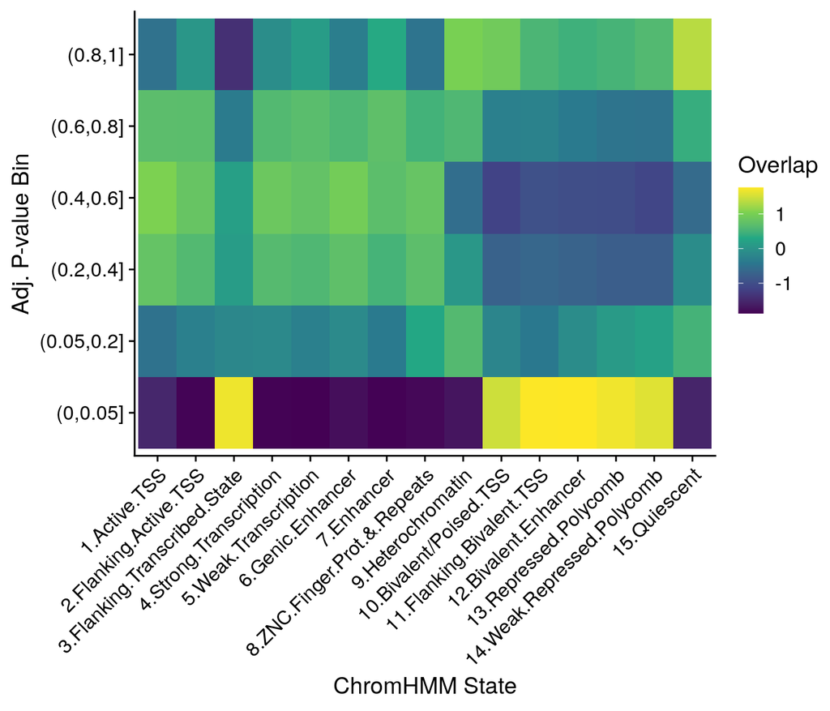

```r
#try standardising across states
scl_annot_mtrx <- apply(annot_mtrx,2,function(x) scale(x)[,1])
#plot
scl_annot_df<-reshape2::melt(scl_annot_mtrx)
names(scl_annot_df) <- c("q-value","State","Overlap")
#Add better explaining state names
scl_annot_df <- scl_annot_df%>%
    mutate(State_name = as.factor(case_when(
        .$State == "E1" ~ "1.Active.TSS",
        .$State == "E2" ~ "2.Flanking.Active.TSS",
        .$State == "E3" ~ "3.Flanking.Transcribed.State",
        .$State == "E4" ~ "4.Strong.Transcription",
        .$State == "E5" ~ "5.Weak.Transcription",
        .$State == "E6" ~ "6.Genic.Enhancer",
        .$State == "E7" ~ "7.Enhancer",
        .$State == "E8" ~ "8.ZNC.Finger.Prot.&.Repeats",
        .$State == "E9" ~ "9.Heterochromatin",
        .$State == "E10" ~ "10.Bivalent/Poised.TSS",
        .$State == "E11" ~ "11.Flanking.Bivalent.TSS",
        .$State == "E12" ~ "12.Bivalent.Enhancer",
        .$State == "E13" ~ "13.Repressed.Polycomb",
        .$State == "E14" ~ "14.Weak.Repressed.Polycomb",
        .$State == "E15" ~ "15.Quiescent")))
# Reorder factor levels for plot
scl_annot_df$State_name <-
    factor(scl_annot_df$State_name,
           levels = levels(scl_annot_df$State_name)[c(1,8:15,2:7)])
ggplot(scl_annot_df,aes(x=State_name,y=`q-value`,fill=Overlap))+
    geom_tile()+theme_cowplot()+scale_fill_viridis_c()+
    theme(axis.text.x = element_text(angle = 45, hjust = 1))+
    xlab("ChromHMM State")+
    ylab("Adj. P-value Bin")
```

Interestingly, this shows that significant interactions are found morefrequently in the inactive or poised regions of the genome. This may suggest that significant interactions may play more of a role in preventing transcription (**NB** Need to discuss this further….).

## Coding Vs Non-coding RNAs

We next wanted to investigate whether different classifications of RNA were found to have significant interactions at different locations in the genome.

Here, we are interested in if the interaction was cis/trans, the distance of the interaction and what was the specific type of RNA. We need to thus do some preprocessing to our results:

```r
#add cis, trans indicator
res[is.na(distance),interaction:="trans"]
res[!is.na(distance),interaction:="cis"]

#add in gene type i.e. coding, non-coding
#get gene names added on to results
baits <-
    fread("/rds/general/project/neurogenomics-lab/live/Projects/radicl_seq/data/all_genes_location.txt",
            header = FALSE,stringsAsFactors = FALSE)
colnames(baits) <- c("chr","start","end","bait_name")
res[,bait_name := baits$bait_name[match(res$bait.start,baits$start)]]

genes <- unique(res$bait_name)
mart <- useMart("ENSEMBL_MART_ENSEMBL", host = "useast.ensembl.org")
mart <- useDataset("hsapiens_gene_ensembl", mart)
annotLookup <- getBM(
    mart = mart,
    attributes = c(
        "hgnc_symbol",
        "entrezgene_id",
        "ensembl_gene_id",
        "gene_biotype"),
    filter = "hgnc_symbol",
    values = genes,
    uniqueRows=TRUE,
    useCache = FALSE)

annotLookup <- as.data.table(annotLookup)

#gene_biotype
setnames(annotLookup,
            c("bait_name","entrezgene_id","ensembl_gene_id","gene_biotype"))
setkey(res,bait_name)
setkey(annotLookup,bait_name)
res[annotLookup,gene_biotype:= i.gene_biotype]
#clear memory
rm(genes,annotLookup,mart,baits)
#10,004,838 with 1,716,157 without
res_biotyp <- res[!is.na(gene_biotype),]
```

We have 10 million interactions that have a related RNA type in `BiomaRt` which can be investigated. These biotype annotations are from [ENSEMBL](http://www.ensembl.org/info/genome/genebuild/biotypes.html). The annotations are quite low-level so we are going to roll up as follows:

- Pseudogene: A gene that has homology to known protein-coding genes but contain a frameshift and/or stop codon(s) which disrupts the ORF. Thought to have arisen through duplication followed by loss of function
- Protein coding: Gene/transcipt that contains an open reading frame (ORF).
- TR gene: T cell receptor gene that undergoes somatic recombination, annotated in collaboration with [IMGT](http://www.imgt.org/)
- TEC(To be Experimentally Confirmed): Regions with EST clusters that have polyA features that could indicate the presence of protein coding genes. These require experimental validation, either by 5’ RACE or RT-PCR to extend the transcripts, or by confirming expression of the putatively-encoded peptide with specific antibodies.
- ncRNA: A non-coding gene + Long non-coding RNA (lncRNA) A non-coding gene/transcript >200bp in length
- Mt_RNA: mitochondrial RNA
- Ribozyme: ribozymal RNA
- scRNA: A small conditional RNA (scRNA) is a small RNA molecule or complex (typically less than approximately 100 nt) engineered to interact and change conformation conditionally in response to cognate molecular inputs so as to perform signal transduction in vitro, in situ, or in vivo.(DEF FROM WIKIPEDIA)
- IG gene: Immunoglobulin gene that undergoes somatic recombination, annotated in collaboration with IMGT http://www.imgt.org/.

```r
res_biotyp[grepl( "protein_coding", gene_biotype),gene_biotype_hl:="pcRNA"]
res_biotyp[grepl( "pseudogene", gene_biotype),gene_biotype_hl:="pseudogene"]
res_biotyp[grepl( "TR_", gene_biotype),gene_biotype_hl:="TR_gene"]
res_biotyp[grepl( "TEC", gene_biotype),gene_biotype_hl:=gene_biotype]
res_biotyp[gene_biotype %in% c("miRNA","miscRNA","piRNA","rRNA","siRNA","snRNA",
                                "snoRNA","tRNA","vaultRNA","lncRNA","misc_RNA",
                                "scaRNA"),
           gene_biotype_hl:="ncRNA"]
res_biotyp[grepl( "Mt_", gene_biotype),gene_biotype_hl:="Mt_RNA"]
res_biotyp[gene_biotype=="ribozyme",gene_biotype_hl:=gene_biotype]
res_biotyp[gene_biotype=="scRNA",gene_biotype_hl:=gene_biotype]
res_biotyp[grepl( "IG_", gene_biotype),gene_biotype_hl:="IG_gene"]
```

The first thing we wanted to know was whether there was a difference in the type of RNA that are involved in cis or trans interactions:

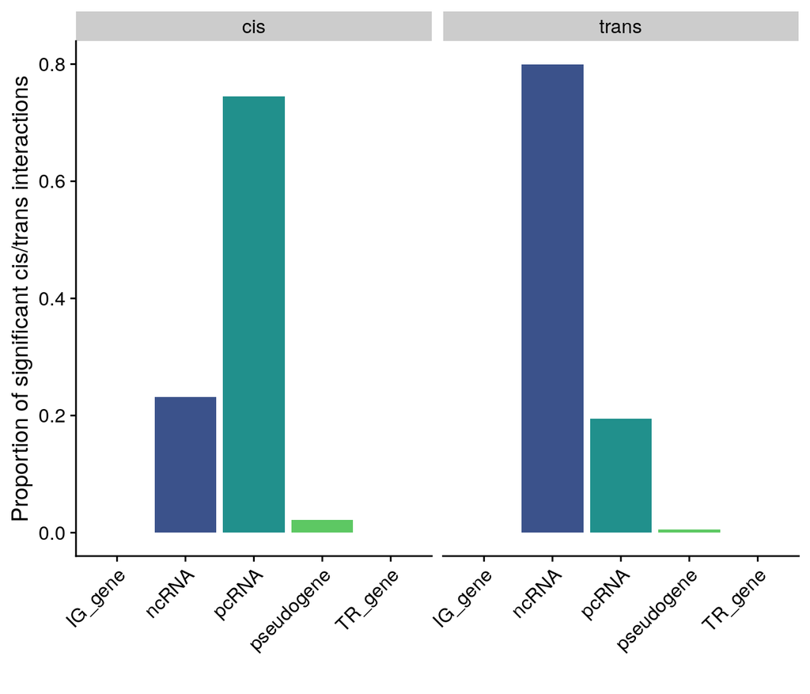

```r
#plot sig with higher and lower level RNA types
#add proportional counts
res_counts <- res_biotyp[q.value<0.05,.N,by=.(interaction,gene_biotype_hl)]
res_counts[,all_N:=sum(N),by=interaction]
res_counts[,prop:=(N/all_N)]
ggplot(res_counts,aes(x=gene_biotype_hl,y=prop,fill=gene_biotype_hl)) +
    geom_bar(stat="identity")+
    facet_wrap(~interaction)+
    theme_cowplot()+
    scale_fill_viridis(discrete=T)+
    theme(axis.text.x = element_text(angle = 45, hjust = 1),
            legend.position="none")+
    xlab("")+
    ylab("Proportion of significant cis/trans interactions")
```

It is clear that there is preferential for non-coding RNA to have trans-interactions whereas the opposite is true for protein-coding RNA. We can see which non-coding RNA are typically involved too:

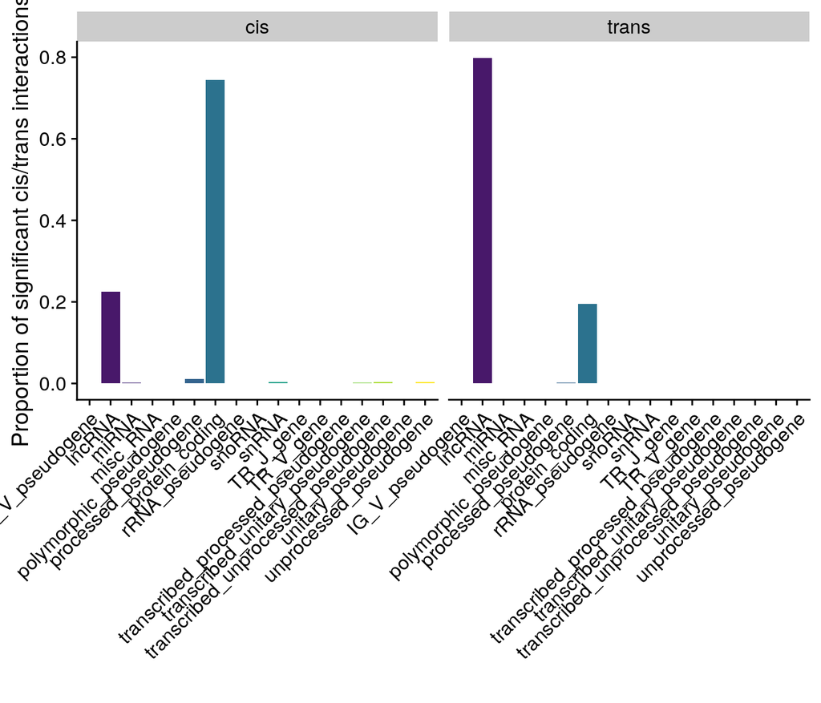

```r
res_counts <- res_biotyp[q.value<0.05,.N,by=.(interaction,gene_biotype)]
res_counts[,all_N:=sum(N),by=interaction]
res_counts[,prop:=(N/all_N)]
ggplot(res_counts, aes(x=gene_biotype,y=prop,fill=gene_biotype)) +
    geom_bar(stat="identity")+
    facet_wrap(~interaction)+
    theme_cowplot()+
    scale_fill_viridis(discrete=T)+
    theme(axis.text.x = element_text(angle = 45, hjust = 1),
          legend.position="none")+
    xlab("")+
    ylab("Proportion of significant cis/trans interactions")
```

The vast majority are long non-coding RNAs (**NB** Need to discuss this further….).

Given that most trans interactions are non-coding RNA’s, we wondered whether there was a relationship between the distance of the interaction from where the RNA was transcribed and the RNA type. Since we can’t derive the distance for trans interactions, we will only consider cis:

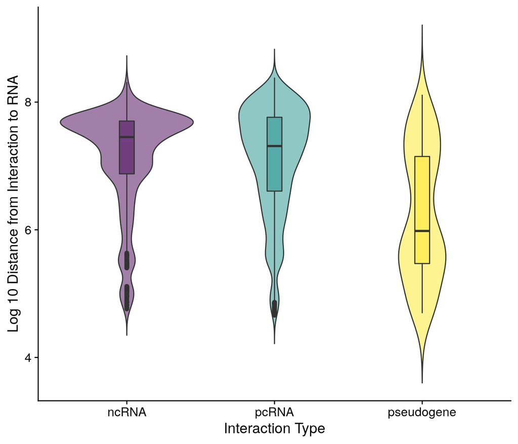

```r
#finally for cis what is the difference in distance of interaction across
#diff RNA types
#Remove IG TR, only 2,3 interactions respectively
ggplot(res_biotyp[q.value<0.05 & interaction=="cis" &
                      (!gene_biotype_hl %in% c("IG_gene","TR_gene"))],
       aes(x=gene_biotype_hl,y=log(distance,base=10),fill=gene_biotype_hl)) +
    geom_violin(trim=FALSE)+
    geom_boxplot(width=0.1)+
    theme_cowplot()+
    scale_fill_viridis(discrete=T,alpha=0.5)+
    theme(legend.position="none")+
    ylab("Log 10 Distance from Interaction to RNA")+
    xlab("Interaction Type")
```

No clear relationship but what if, as before, we look at specific types of non-coding RNA

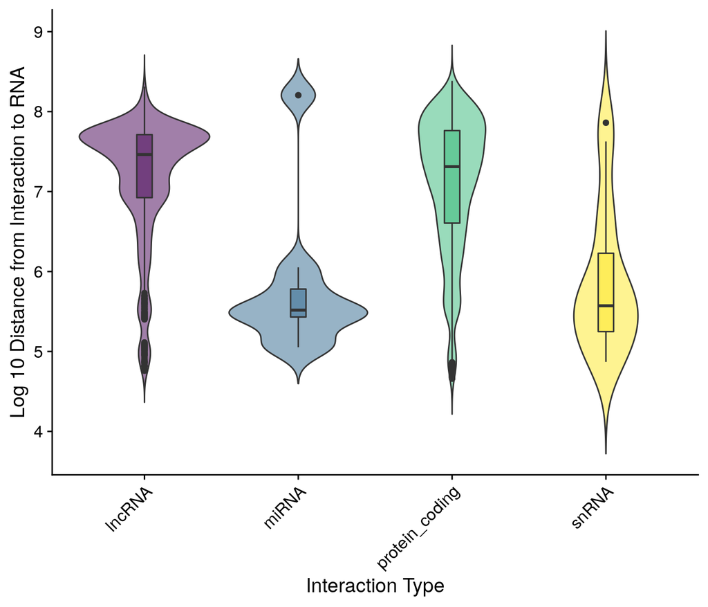

```r
#snoRNA,misc_RNA removed too low cases - 2,3
#removed pseudogene RNAs too to compare coding and non-coding directly
ggplot(res_biotyp[q.value<0.05 & interaction=="cis" &
                      (!gene_biotype_hl %in% c("IG_gene","TR_gene",
                                                "pseudogene")) &
                      (!gene_biotype %in%
                           c("snoRNA","misc_RNA"))],
       aes(x=gene_biotype,y=log(distance,base=10),fill=gene_biotype)) +
    geom_violin(trim=FALSE)+
    geom_boxplot(width=0.1)+
    theme_cowplot()+
    scale_fill_viridis(discrete=T,alpha=0.5)+
    theme(axis.text.x = element_text(angle = 45, hjust = 1),
            legend.position="none")+
    ylab("Log 10 Distance from Interaction to RNA")+
    xlab("Interaction Type")
```

We can look into these differences further but first, let’s consider the differences between significant cis and trans interactions. There are 34627 significant interactions. Of these, 84.2% are trans whereas 15.8% are cis. Is there a small number of RNAs contributing to all of these cis or trans interactions?

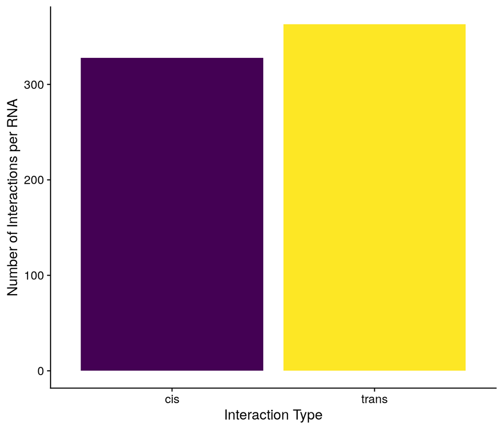

```r
#get the number of interactions per RNA for trans/cis
res_meta <- res[q.value<0.05,list(sum(count),length(unique(bait_name))),
      by=interaction]
res_meta[,prop:=V1/V2]

#now get
ggplot(res_meta,
       aes(x=interaction,y=prop,fill=interaction)) +
  geom_bar(stat="identity")+
  theme_cowplot()+
  scale_fill_viridis(discrete=T)+
  theme(legend.position="none")+
  ylab("Number of Interactions per RNA")+
  xlab("Interaction Type")
```

Roughly the same number of interactions per RNA for trans and cis interactions.

What if interactions associated with Malat1 and Neat1 are dropped, how does that affect: vast majority (80%+) of trans interactions are by non-coding RNA; predominately lncRNAs and the majority of cis are by protein coding RNAs (75%+)?

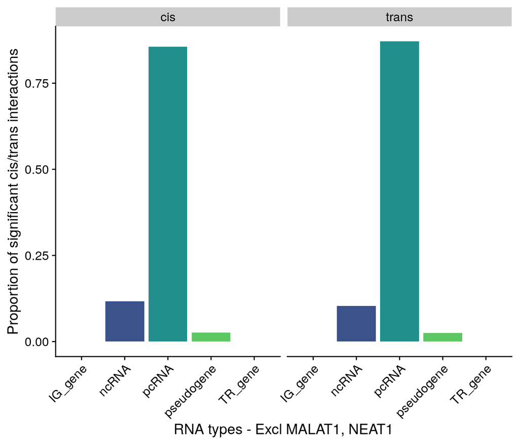

```r
#remove Malat1 and Neat1 and then replot
#plot sig with higher and lower level RNA types
#add proportional counts
res_counts_excl <- res_biotyp[q.value<0.05 & !(bait_name %in%
                                                  c("MALAT1","NEAT1")),
                                .N,by=.(interaction,gene_biotype_hl)]
res_counts_excl[,all_N:=sum(N),by=interaction]
res_counts_excl[,prop:=(N/all_N)]
ggplot(res_counts_excl,aes(x=gene_biotype_hl,y=prop,fill=gene_biotype_hl)) +
  geom_bar(stat="identity")+
  facet_wrap(~interaction)+
  theme_cowplot()+
  scale_fill_viridis(discrete=T)+
  theme(axis.text.x = element_text(angle = 45, hjust = 1),
        legend.position="none")+
  xlab("RNA types - Excl MALAT1, NEAT1")+
  ylab("Proportion of significant cis/trans interactions")
```

So when MALAT1 and NEAT1 are removed, both cis and trans interactions appear to have the same proportions of RNA types with preferential binding. Does this hold for the RNA subtypes?

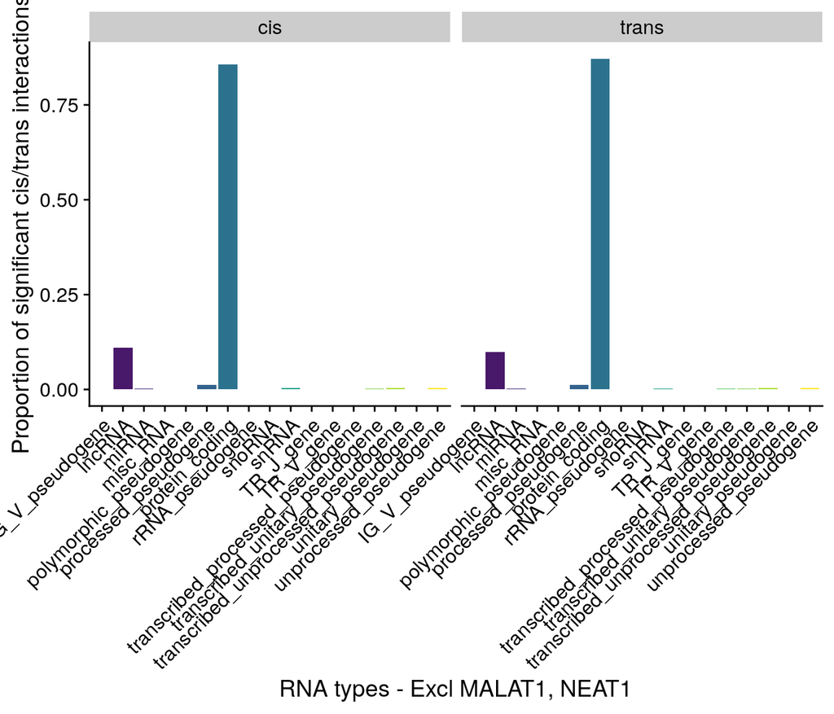

```r
res_counts_excl <- res_biotyp[q.value<0.05 & !(bait_name %in%
                                                  c("MALAT1","NEAT1")),
                                .N,by=.(interaction,gene_biotype)]
res_counts_excl[,all_N:=sum(N),by=interaction]
res_counts_excl[,prop:=(N/all_N)]
ggplot(res_counts_excl, aes(x=gene_biotype,y=prop,fill=gene_biotype)) +
  geom_bar(stat="identity")+
  facet_wrap(~interaction)+
  theme_cowplot()+
  scale_fill_viridis(discrete=T)+
  theme(axis.text.x = element_text(angle = 45, hjust = 1),
        legend.position="none")+
  xlab("RNA types - Excl MALAT1, NEAT1")+
  ylab("Proportion of significant cis/trans interactions")
```

Again the proportions appear identical when MALAT1 and NEAT1 are excluded.

*TO DO* - Next I’d ideally like to annotate the DNA these RNA Bind to (similar to ChromHMM but giving……)